# Replication of the Epistemic Side‑Effect Effect (ESEE) in Polish on a Representative Sample

Bartosz Maćkiewicz, Marta Zaręba, Katarzyna Kuś, Katarzyna Paprzycka‑Hausman

### Simplified codebook

- **ID** – anonymous identifier assigned by the survey platform; unique per participant.
- **survey_finish_time** – total completion time for the whole questionnaire, recorded in **seconds** (numeric).
- **sex** – self‑reported biological sex with four response options: *Kobieta* (female), *Mężczyzna* (male), *Inna* (other), *Nie chcę udzielać odpowiedzi* (prefer not to say).
- **sex2** – free‑text clarification shown **only** when *sex = “Inna”*; respondents may leave it blank.
- **age** – age bin chosen from the panel provider’s standard categories
- **edu** – highest level of completed education (ordered from lowest to highest):
  - *Podstawowe* — **Primary education**
  - *Zawodowe lub policealne* — **Vocational or post‑secondary diploma**
  - *Średnie* — **Secondary education / high‑school diploma**
  - *Wyższe licencjackie lub inżynierskie* — **Bachelor’s or Engineering degree**
  - *Wyższe magisterskie* — **Master’s degree (MA/MSc)**
  - *Doktorat lub więcej* — **Doctorate or higher**
- **year** – numeric age in full years (continuous).
- **location** – five‑level place‑of‑residence item: *wieś* (village), *małe miasto* (≤ 20 k), *średnie miasto* (20–99 k), *duże miasto* (100–500 k), *wielkie miasto* (> 500 k).
- **location2** – additional 2‑level split of the middle categories (*20–49 k* vs. *50–99 k*).
- **location3** – additional 2‑level split of the upper‑middle categories (*100–200 k* vs. *200–500 k*).
- **KLikert** – agreement level to “The CEO knew that … *harm/help* …?” (see **Form** for details on phrasing) answered on a **7‑point Likert scale** from ‑3 (*zdecydowanie nie*, *strongly disagree*) to +3 (*zdecydowanie tak*, *strongly agree*).
- **KBinary** – same question in a **forced‑choice** format: `1 = "Tak" ("Yes")`, `0 = "Nie" ("No")`.
- **KBinaryAll** – unified three‑level factor combining both formats: *Yes* / *No* / *Neither* (neutral midpoint of the Likert scale).
- **KExpl** – open‑choice justification (Polish wording) for the knowledge attribution. The form displayed depends on the respondent’s earlier answer:
  - *Positive* claim (> 0 or `1`):
    - The CEO had reasons to believe that he would harm the environment.
    - The CEO believed that he would harm the environment.
    - The CEO was aware that he could harm the environment.
    - Other (explain)
  - *Negative* claim (< 0 or `0`): symmetrical negations of the above.
    - The CEO had no reasons to believe that he would harm the environment.
    - The CEO did not believe that he would harm the environment.
    - The CEO was not aware that he could harm the environment.
    - Other (explain)
  - *Neutral* (`0` only):
    - It was not clear whether the CEO had reasons to believe that he would harm the environment.
    - It was not clear whether the CEO believed that he would harm the environment.
    - It was not clear whether the CEO was aware that he could harm the environment.
    - Other (explain)
- **KExplSimple** – single‑letter code extracted from **KExpl**:
  - `B` = *Belief* (CEO believed)
  - `Q` = *Awareness* (CEO was aware)
  - `R` = *Reasons* (CEO had reasons)
  - `O` = *Other* / uncategorised text
- **KExplOther** – text for `O` option
- **KProfits** –agreement level to “The CEO knew the program would increase profits”; 7‑point Likert (‑3…+3) mirroring **KLikert**
- **Int** –agreement level to intentionality attribution with adverb *intencjonalnie* (“intentionally”); Likert ‑3…+3.
- **IntUmyślnie** – agreement level to intentionality attribution with adverb *umyślnie* (“deliberately”); Likert ‑3…+3.
- **IntCelowo** – agreement level to intentionality attribution with adverb *celowo* (“purposefully”); Likert ‑3…+3.
- **IntŚwiadomie** – agreement level to intentionality attribution with adverb *świadomie* (“knowingly”); Likert ‑3…+3.
- **Intention** – agreement level to intention attribution with phrasing *miał intencję, aby…* (“had the intention to…”); Likert ‑3…+3.
- **BSądził** – agreement level to belief attribution using verb *sądził* (“judged / thought”); Likert ‑3…+3.
- **BPrzekonany** – agreement level to belief attribution using phrase *był przekonany* (“believed”); Likert ‑3…+3.
- **Aware** – agreement level to awareness attribution *był świadomy* (“was aware”).
- **Reasons** – agreement level to reason attribution *miał powody* (“had reasons”).
- **Condition** – vignette type manipulated between subjects: `Harm` (environment worsens) or `Help` (environment improves).
- **Scale** – response format for the knowledge item: `LIK` = 7‑point Likert, `FC` = forced choice.
- **Form** – wording of the knowledge statement shown before the response:
  - `AG` – **Agentive**: *Dyrektor wiedział, że zaszkodzi/pomoże środowisku* (“The CEO knew he would harm/help the environment”).
  - `PR` – **Causal**: *Dyrektor wiedział, że wdrożenie programu pomoże/zaszkodzi środowisku* (“…that implementing the programme would help/harm the environment”).
  - `ST` – **State‑change**: *Dyrektor wiedział, że stan środowiska się pogorszy/polepszy* (“…that the state of the environment would get worse/better”).

# Demographics

## Sex/gender

| Inna | Kobieta | Mężczyzna | Nie chcę udzielać odpowiedzi |
| --- | --- | --- | --- |
| 4 | 676 | 629 | 1 |

## Age

| M | SD |
| --- | --- |
| 45.14 | 16.41 |

## Location

Table continues below

| duże miasto (od 100 do 500 tys. mieszkańców) | małe miasto (do 20 tys. mieszkańców) |
| --- | --- |
| 0.1695 | 0.1313 |

| średnie miasto (od 20 do 99 tys. mieszkańców) | wielkie miasto (powyżej 500 tys. mieszkańców) | wieś |
| --- | --- | --- |
| 0.2015 | 0.1229 | 0.3748 |

| 20 – 49 tys. mieszkańców | 50 – 99 tys. mieszkańców |
| --- | --- |
| 125 | 139 |

| 100 – 200 tys. mieszkańców | 200 – 500 tys. mieszkańców |
| --- | --- |
| 105 | 117 |

## Education

Table continues below

| Doktorat lub więcej | Podstawowe | Średnie | Wyższe licencjackie lub inżynierskie |
| --- | --- | --- | --- |
| 14 | 39 | 443 | 138 |

| Wyższe magisterskie | Zawodowe lub policealne |
| --- | --- |
| 415 | 261 |

## Number of participants in each condition

| Condition | Scale | Form | n |
| --- | --- | --- | --- |
| Harm | FC | AG | 111 |
| Harm | FC | PR | 110 |
| Harm | FC | ST | 101 |
| Harm | LIK | AG | 111 |
| Harm | LIK | PR | 105 |
| Harm | LIK | ST | 113 |
| Help | FC | AG | 107 |
| Help | FC | PR | 111 |
| Help | FC | ST | 106 |
| Help | LIK | AG | 116 |
| Help | LIK | PR | 115 |
| Help | LIK | ST | 104 |

# Results

## Knowedge

### Likert format

| Form | Condition | M | SD | n |
| --- | --- | --- | --- | --- |
| AG | Harm | 2.36 | 1.24 | 111 |
| AG | Help | 0.30 | 2.07 | 116 |
| PR | Harm | 2.29 | 1.54 | 105 |
| PR | Help | 0.68 | 2.10 | 115 |
| ST | Harm | 2.42 | 1.35 | 113 |
| ST | Help | 0.15 | 2.05 | 104 |

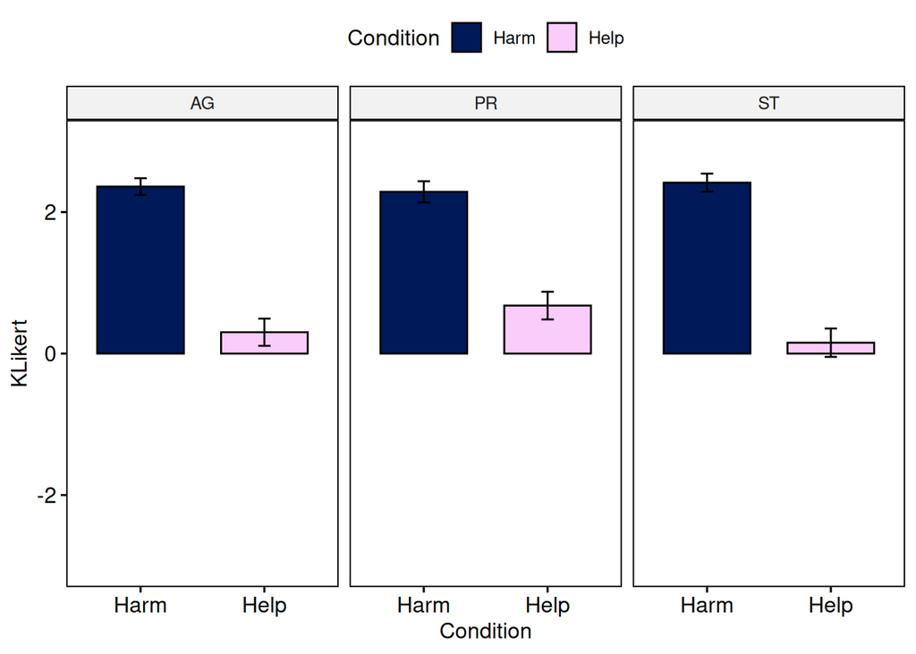

### Forced-choice format

| Form | Condition | % | n |
| --- | --- | --- | --- |
| AG | Harm | 98.20 | 111 |
| AG | Help | 56.07 | 107 |
| PR | Harm | 93.64 | 110 |
| PR | Help | 68.47 | 111 |
| ST | Harm | 91.09 | 101 |
| ST | Help | 55.66 | 106 |

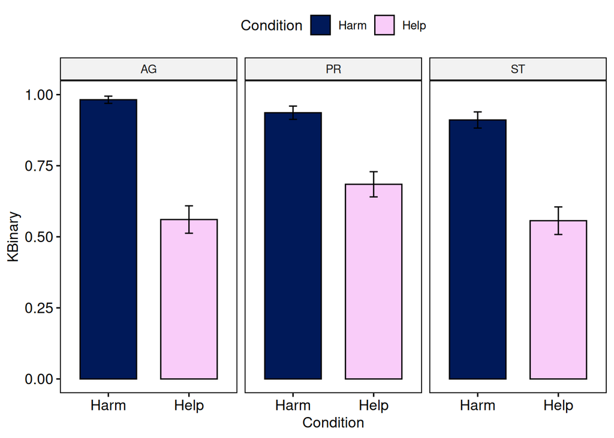

## Rest of the questions

### Splitted

| question | Scale | Form | Condition | M | SD | n |
| --- | --- | --- | --- | --- | --- | --- |
| Aware | FC | AG | Harm | 2.37 | 0.98 | 111 |
| Aware | FC | AG | Help | 0.38 | 2.07 | 107 |
| Aware | FC | PR | Harm | 2.38 | 1.11 | 110 |
| Aware | FC | PR | Help | 0.80 | 1.99 | 111 |
| Aware | FC | ST | Harm | 2.26 | 1.28 | 101 |
| Aware | FC | ST | Help | 0.24 | 1.95 | 106 |
| Aware | LIK | AG | Harm | 2.38 | 1.20 | 111 |
| Aware | LIK | AG | Help | 0.14 | 2.03 | 116 |
| Aware | LIK | PR | Harm | 2.51 | 1.04 | 105 |
| Aware | LIK | PR | Help | 0.73 | 1.99 | 115 |
| Aware | LIK | ST | Harm | 2.53 | 0.95 | 113 |
| Aware | LIK | ST | Help | 0.12 | 1.80 | 104 |
| BPrzekonany | FC | AG | Harm | 1.97 | 1.24 | 111 |
| BPrzekonany | FC | AG | Help | -0.36 | 2.00 | 107 |
| BPrzekonany | FC | PR | Harm | 1.98 | 1.37 | 110 |
| BPrzekonany | FC | PR | Help | -0.14 | 2.03 | 111 |
| BPrzekonany | FC | ST | Harm | 1.96 | 1.45 | 101 |
| BPrzekonany | FC | ST | Help | -0.25 | 1.98 | 106 |
| BPrzekonany | LIK | AG | Harm | 2.03 | 1.32 | 111 |
| BPrzekonany | LIK | AG | Help | -0.31 | 1.94 | 116 |
| BPrzekonany | LIK | PR | Harm | 1.98 | 1.37 | 105 |
| BPrzekonany | LIK | PR | Help | -0.11 | 2.01 | 115 |
| BPrzekonany | LIK | ST | Harm | 2.20 | 1.13 | 113 |
| BPrzekonany | LIK | ST | Help | -0.28 | 1.81 | 104 |
| BSądził | FC | AG | Harm | 1.51 | 1.70 | 111 |
| BSądził | FC | AG | Help | -0.53 | 1.83 | 107 |
| BSądził | FC | PR | Harm | 1.62 | 1.68 | 110 |
| BSądził | FC | PR | Help | -0.26 | 1.95 | 111 |
| BSądził | FC | ST | Harm | 1.29 | 1.94 | 101 |
| BSądził | FC | ST | Help | -0.17 | 1.82 | 106 |

[output cut: 90 more lines]

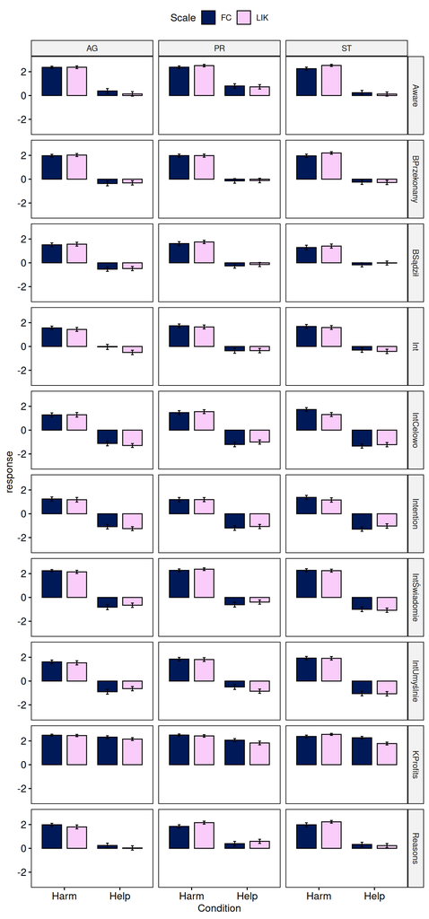

### Splitted belief

| question | Form | Condition | M | SD | n |
| --- | --- | --- | --- | --- | --- |
| BPrzekonany | AG | Harm | 2.00 | 1.28 | 222 |
| BPrzekonany | AG | Help | -0.34 | 1.96 | 223 |
| BPrzekonany | PR | Harm | 1.98 | 1.36 | 215 |
| BPrzekonany | PR | Help | -0.13 | 2.01 | 226 |
| BPrzekonany | ST | Harm | 2.09 | 1.29 | 214 |
| BPrzekonany | ST | Help | -0.26 | 1.89 | 210 |
| BSądził | AG | Harm | 1.54 | 1.70 | 222 |
| BSądził | AG | Help | -0.51 | 1.86 | 223 |
| BSądził | PR | Harm | 1.68 | 1.54 | 215 |
| BSądził | PR | Help | -0.20 | 1.90 | 226 |
| BSądził | ST | Harm | 1.35 | 1.88 | 214 |
| BSądził | ST | Help | -0.10 | 1.78 | 210 |

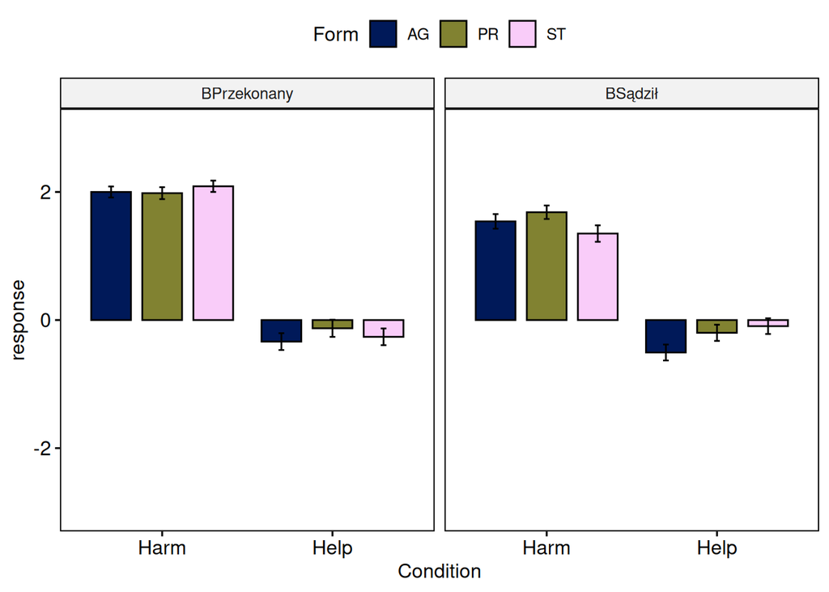

Table continues below

|  | Effect | DFn | DFd | F | p | p<.05 |
| --- | --- | --- | --- | --- | --- | --- |
| **2** | Condition | 1 | 1304 | 552.5 | 3.737e-102 | * |
| **3** | Form | 2 | 1304 | 1.184 | 0.3064 |  |
| **5** | question | 1 | 1304 | 41.93 | 1.337e-10 | * |
| **4** | Condition:Form | 2 | 1304 | 0.998 | 0.3689 |  |
| **6** | Condition:question | 1 | 1304 | 33.41 | 9.316e-09 | * |
| **7** | Form:question | 2 | 1304 | 0.9344 | 0.3931 |  |
| **8** | Condition:Form:question | 2 | 1304 | 7.052 | 0.0008993 | * |

|  | ges |
| --- | --- |
| **2** | 0.2579 |
| **3** | 0.001487 |
| **5** | 0.005745 |
| **4** | 0.001254 |
| **6** | 0.004583 |
| **7** | 0.0002575 |
| **8** | 0.00194 |

### For all conditions combined

| question | Condition | M | SD | n |
| --- | --- | --- | --- | --- |
| Aware | Harm | 2.41 | 1.09 | 651 |
| Aware | Help | 0.41 | 1.99 | 659 |
| BPrzekonany | Harm | 2.02 | 1.31 | 651 |
| BPrzekonany | Help | -0.24 | 1.96 | 659 |
| BSądził | Harm | 1.53 | 1.72 | 651 |
| BSądził | Help | -0.27 | 1.85 | 659 |
| Int | Harm | 1.61 | 1.65 | 651 |
| Int | Help | -0.33 | 2.03 | 659 |
| IntCelowo | Harm | 1.43 | 1.76 | 651 |
| IntCelowo | Help | -1.20 | 1.89 | 659 |
| IntUmyślnie | Harm | 1.77 | 1.61 | 651 |
| IntUmyślnie | Help | -0.83 | 2.00 | 659 |
| Intention | Harm | 1.22 | 1.85 | 651 |
| Intention | Help | -1.15 | 1.91 | 659 |
| IntŚwiadomie | Harm | 2.26 | 1.25 | 651 |
| IntŚwiadomie | Help | -0.75 | 1.99 | 659 |
| KProfits | Harm | 2.46 | 0.99 | 651 |
| KProfits | Help | 2.07 | 1.34 | 659 |
| Reasons | Harm | 2.00 | 1.44 | 651 |
| Reasons | Help | 0.31 | 1.93 | 659 |

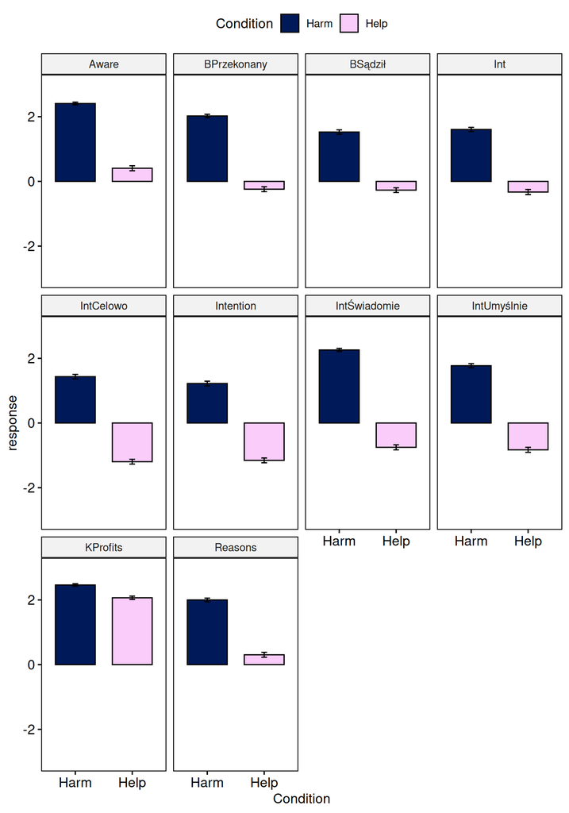

# Further statistical analyses

## Is the formulation of the question statistically significant?

### ANOVA for responses on Likert scale

| Effect | DFn | DFd | F | p | p<.05 | ges |
| --- | --- | --- | --- | --- | --- | --- |
| Condition | 1 | 658 | 207.7 | 3.954e-41 | * | 0.24 |
| Form | 2 | 658 | 0.7871 | 0.4556 |  | 0.002387 |
| Condition:Form | 2 | 658 | 1.97 | 0.1402 |  | 0.005953 |

### Pairwise comparisons for responses on Likert scale

| Condition | .y. | group1 | group2 | n1 | n2 | p | p.signif | p.adj | p.adj.signif |
| --- | --- | --- | --- | --- | --- | --- | --- | --- | --- |
| Harm | KLikert | AG | PR | 111 | 105 | 0.69 | ns | 1.00 | ns |
| Harm | KLikert | AG | ST | 111 | 113 | 0.76 | ns | 1.00 | ns |
| Harm | KLikert | PR | ST | 105 | 113 | 0.49 | ns | 1.00 | ns |
| Help | KLikert | AG | PR | 116 | 115 | 0.17 | ns | 0.34 | ns |
| Help | KLikert | AG | ST | 116 | 104 | 0.60 | ns | 0.60 | ns |
| Help | KLikert | PR | ST | 115 | 104 | 0.06 | ns | 0.19 | ns |

### Pairwise comparisons for responses in fored-choice format

| Condition | group1 | group2 | n | p | p.adj | p.adj.signif |
| --- | --- | --- | --- | --- | --- | --- |
| Harm | AG | PR | 221 | 0.10 | 0.10 | ns |
| Harm | AG | ST | 212 | 0.03 | 0.03 |  |
| Harm | PR | ST | 211 | 0.60 | 0.60 | ns |
| Help | AG | PR | 218 | 0.07 | 0.07 | ns |
| Help | AG | ST | 213 | 1.00 | 1.00 | ns |
| Help | PR | ST | 217 | 0.07 | 0.07 | ns |

# Table with three formulations separately

| Scale | Form | Condition | Kc | Percent_B | n_B | Percent_Q | n_Q | Percent_R | n_R | Percent_O | n_O |
| --- | --- | --- | --- | --- | --- | --- | --- | --- | --- | --- | --- |
| FC | AG | Harm | No |  |  | 100.00 | 2 |  |  |  |  |
| FC | AG | Harm | Yes | 30.28 | 33 | 55.96 | 61 | 11.93 | 13 | 1.83 | 2 |
| FC | AG | Help | No | 21.28 | 10 | 53.19 | 25 | 21.28 | 10 | 4.26 | 2 |
| FC | AG | Help | Yes | 15.00 | 9 | 61.67 | 37 | 21.67 | 13 | 1.67 | 1 |
| FC | PR | Harm | No | 28.57 | 2 | 42.86 | 3 | 28.57 | 2 |  |  |
| FC | PR | Harm | Yes | 26.21 | 27 | 63.11 | 65 | 9.71 | 10 | 0.97 | 1 |
| FC | PR | Help | No | 22.86 | 8 | 57.14 | 20 | 14.29 | 5 | 5.71 | 2 |
| FC | PR | Help | Yes | 9.21 | 7 | 64.47 | 49 | 19.74 | 15 | 6.58 | 5 |
| FC | ST | Harm | No | 22.22 | 2 | 55.56 | 5 | 22.22 | 2 |  |  |
| FC | ST | Harm | Yes | 34.78 | 32 | 53.26 | 49 | 7.61 | 7 | 4.35 | 4 |
| FC | ST | Help | No | 14.89 | 7 | 51.06 | 24 | 21.28 | 10 | 12.77 | 6 |
| FC | ST | Help | Yes | 15.25 | 9 | 59.32 | 35 | 15.25 | 9 | 10.17 | 6 |
| LIK | AG | Harm | Neither | 70.00 | 7 | 20.00 | 2 | 10.00 | 1 |  |  |
| LIK | AG | Harm | No |  |  | 33.33 | 1 |  |  | 66.67 | 2 |
| LIK | AG | Harm | Yes | 36.73 | 36 | 60.20 | 59 | 2.04 | 2 | 1.02 | 1 |
| LIK | AG | Help | Neither | 35.00 | 7 | 40.00 | 8 | 25.00 | 5 |  |  |
| LIK | AG | Help | No | 15.00 | 6 | 47.50 | 19 | 22.50 | 9 | 15.00 | 6 |
| LIK | AG | Help | Yes | 10.71 | 6 | 69.64 | 39 | 12.50 | 7 | 7.14 | 4 |
| LIK | PR | Harm | Neither | 42.86 | 3 | 28.57 | 2 | 28.57 | 2 |  |  |
| LIK | PR | Harm | No |  |  | 42.86 | 3 |  |  | 57.14 | 4 |
| LIK | PR | Harm | Yes | 31.87 | 29 | 60.44 | 55 | 7.69 | 7 |  |  |
| LIK | PR | Help | Neither | 26.32 | 5 | 57.89 | 11 | 10.53 | 2 | 5.26 | 1 |
| LIK | PR | Help | No | 31.25 | 10 | 43.75 | 14 | 18.75 | 6 | 6.25 | 2 |
| LIK | PR | Help | Yes | 12.50 | 8 | 67.19 | 43 | 15.62 | 10 | 4.69 | 3 |
| LIK | ST | Harm | Neither | 50.00 | 2 |  |  | 25.00 | 1 | 25.00 | 1 |
| LIK | ST | Harm | No | 20.00 | 1 | 60.00 | 3 |  |  | 20.00 | 1 |
| LIK | ST | Harm | Yes | 28.85 | 30 | 57.69 | 60 | 12.50 | 13 | 0.96 | 1 |
| LIK | ST | Help | Neither | 16.67 | 3 | 44.44 | 8 | 38.89 | 7 |  |  |
| LIK | ST | Help | No | 13.51 | 5 | 51.35 | 19 | 27.03 | 10 | 8.11 | 3 |
| LIK | ST | Help | Yes | 16.33 | 8 | 51.02 | 25 | 32.65 | 16 |  |  |

### Justifications for binary choice

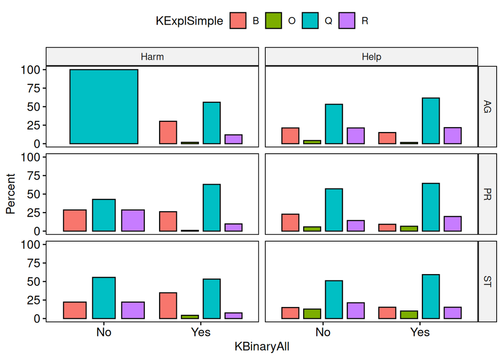

### Justifications for Likert scale

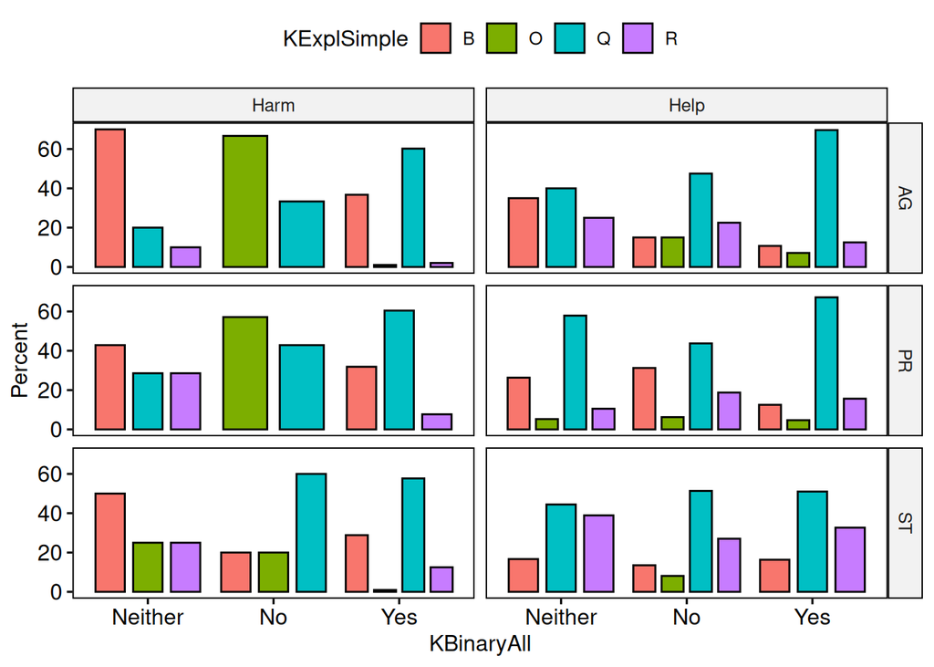

### Table with three formulations together

| Scale | Condition | Kc | Percent_B | n_B | Percent_Q | n_Q | Percent_R | n_R | Percent_O | n_O |
| --- | --- | --- | --- | --- | --- | --- | --- | --- | --- | --- |
| FC | Harm | No | 22.22 | 4 | 55.56 | 10 | 22.22 | 4 |  |  |
| FC | Harm | Yes | 30.26 | 92 | 57.57 | 175 | 9.87 | 30 | 2.30 | 7 |
| FC | Help | No | 19.38 | 25 | 53.49 | 69 | 19.38 | 25 | 7.75 | 10 |
| FC | Help | Yes | 12.82 | 25 | 62.05 | 121 | 18.97 | 37 | 6.15 | 12 |
| LIK | Harm | Neither | 57.14 | 12 | 19.05 | 4 | 19.05 | 4 | 4.76 | 1 |
| LIK | Harm | No | 6.67 | 1 | 46.67 | 7 |  |  | 46.67 | 7 |
| LIK | Harm | Yes | 32.42 | 95 | 59.39 | 174 | 7.51 | 22 | 0.68 | 2 |
| LIK | Help | Neither | 26.32 | 15 | 47.37 | 27 | 24.56 | 14 | 1.75 | 1 |
| LIK | Help | No | 19.27 | 21 | 47.71 | 52 | 22.94 | 25 | 10.09 | 11 |
| LIK | Help | Yes | 13.02 | 22 | 63.31 | 107 | 19.53 | 33 | 4.14 | 7 |

### Justifications

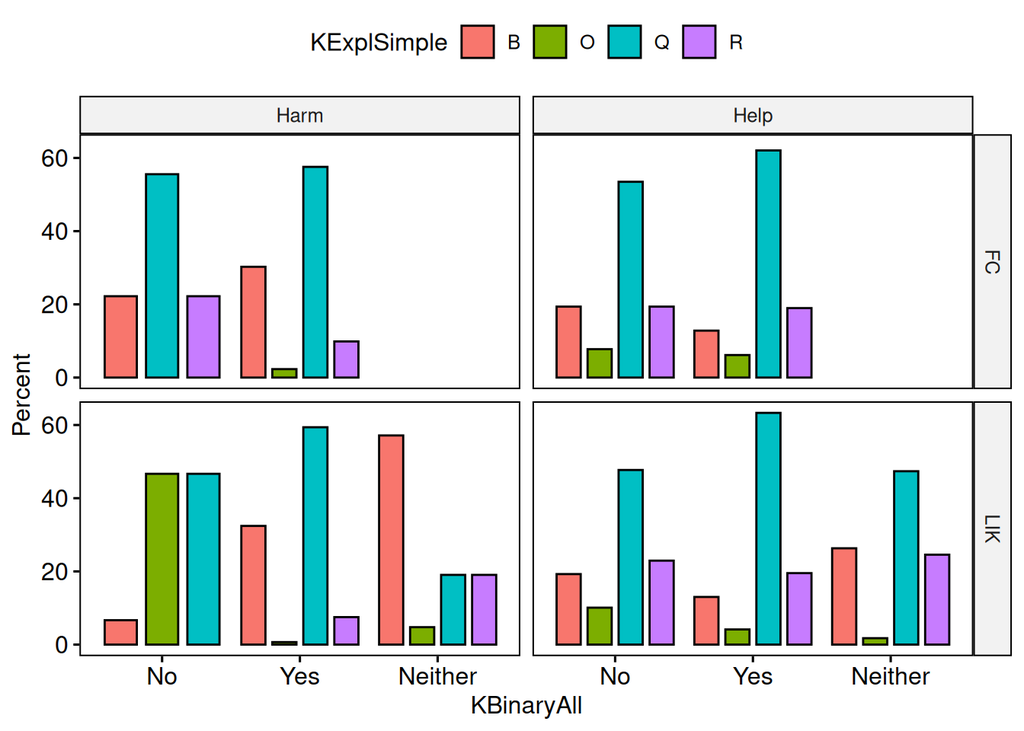

## Meta-analysis

```
##
## Random-Effects Model (k = 6; tau^2 estimator: REML)
##
##   logLik  deviance       AIC       BIC      AICc
##  -2.1907    4.3814    8.3814    7.6003   14.3814
##
## tau^2 (estimated amount of total heterogeneity): 0.0553 (SE = 0.0591)
## tau (square root of estimated tau^2 value):      0.2351
## I^2 (total heterogeneity / total variability):   62.51%
## H^2 (total variability / sampling variability):  2.67
##
## Test for Heterogeneity:
## Q(df = 5) = 13.5909, p-val = 0.0184
##
## Model Results:
##
## estimate      se     tval  df    pval   ci.lb   ci.ub
##   1.2775  0.1262  10.1193   5  0.0002  0.9530  1.6021  ***
##
## ---
## Signif. codes:  0 '***' 0.001 '**' 0.01 '*' 0.05 '.' 0.1 ' ' 1
```

### Forest plot

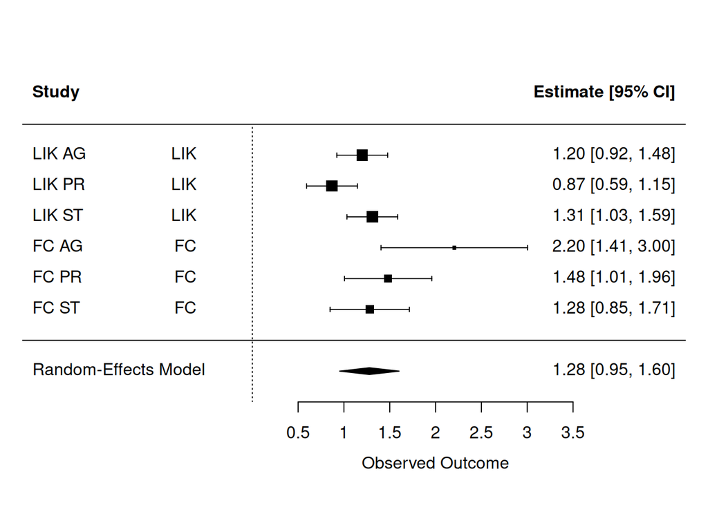

### Meta-regression

```
##
## Multivariate Meta-Analysis Model (k = 6; method: REML)
##
##   logLik  Deviance       AIC       BIC      AICc
##  -1.4890    2.9781   10.9781    5.7507   50.9781
##
## Variance Components: none
##
## Test for Residual Heterogeneity:
## QE(df = 2) = 5.1997, p-val = 0.0743
##
## Test of Moderators (coefficients 2:4):
## F(df1 = 3, df2 = 2) = 2.7971, p-val = 0.2743
##
## Model Results:
##
##           estimate      se     tval  df    pval    ci.lb   ci.ub
## intrcpt     1.6565  0.2057   8.0527   2  0.0151   0.7714  2.5416  *
## ScaleLIK   -0.3906  0.1752  -2.2294   2  0.1556  -1.1445  0.3633
## FormPR     -0.3398  0.1829  -1.8579   2  0.2043  -1.1266  0.4471
## FormST     -0.0779  0.1818  -0.4282   2  0.7102  -0.8603  0.7045
##
## ---
## Signif. codes:  0 '***' 0.001 '**' 0.01 '*' 0.05 '.' 0.1 ' ' 1
```

# Appendix: responses to Likert scane questions collapsed into three categories

## Results

### Knowedge

#### Categorized Likert format and Forced-choice format

| Form | Condition | Scale | n_No | n_Yes | n_Neither | Percent_No | Percent_Yes | Percent_Neither |
| --- | --- | --- | --- | --- | --- | --- | --- | --- |
| AG | Harm | FC | 2 | 109 |  | 1.80 | 98.20 |  |
| AG | Harm | LIK | 3 | 98 | 10 | 2.70 | 88.29 | 9.01 |
| AG | Help | FC | 47 | 60 |  | 43.93 | 56.07 |  |
| AG | Help | LIK | 40 | 56 | 20 | 34.48 | 48.28 | 17.24 |
| PR | Harm | FC | 7 | 103 |  | 6.36 | 93.64 |  |
| PR | Harm | LIK | 7 | 91 | 7 | 6.67 | 86.67 | 6.67 |
| PR | Help | FC | 35 | 76 |  | 31.53 | 68.47 |  |
| PR | Help | LIK | 32 | 64 | 19 | 27.83 | 55.65 | 16.52 |
| ST | Harm | FC | 9 | 92 |  | 8.91 | 91.09 |  |
| ST | Harm | LIK | 5 | 104 | 4 | 4.42 | 92.04 | 3.54 |
| ST | Help | FC | 47 | 59 |  | 44.34 | 55.66 |  |
| ST | Help | LIK | 37 | 49 | 18 | 35.58 | 47.12 | 17.31 |

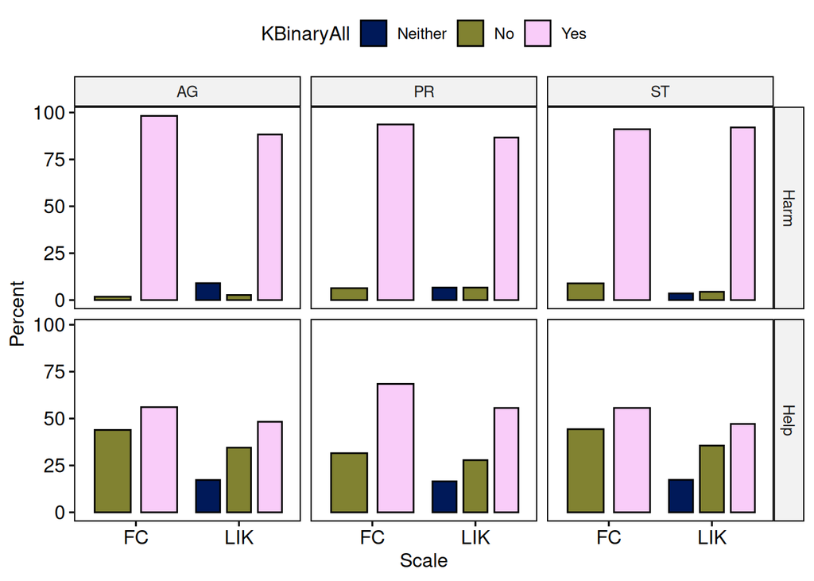

## Rest of the questions

### For all conditions combined

| question | Condition | n_Neither | n_No | n_Yes | Percent_Neither | Percent_No | Percent_Yes |
| --- | --- | --- | --- | --- | --- | --- | --- |
| Aware | Harm | 40 | 15 | 596 | 6.14 | 2.30 | 91.55 |
| Aware | Help | 119 | 190 | 350 | 18.06 | 28.83 | 53.11 |
| BPrzekonany | Harm | 69 | 30 | 552 | 10.60 | 4.61 | 84.79 |
| BPrzekonany | Help | 137 | 275 | 247 | 20.79 | 41.73 | 37.48 |
| BSądził | Harm | 110 | 72 | 469 | 16.90 | 11.06 | 72.04 |
| BSądził | Help | 178 | 260 | 221 | 27.01 | 39.45 | 33.54 |
| Int | Harm | 95 | 65 | 491 | 14.59 | 9.98 | 75.42 |
| Int | Help | 127 | 281 | 251 | 19.27 | 42.64 | 38.09 |
| IntCelowo | Harm | 107 | 88 | 456 | 16.44 | 13.52 | 70.05 |
| IntCelowo | Help | 105 | 416 | 138 | 15.93 | 63.13 | 20.94 |
| IntUmyślnie | Harm | 81 | 55 | 515 | 12.44 | 8.45 | 79.11 |
| IntUmyślnie | Help | 129 | 354 | 176 | 19.58 | 53.72 | 26.71 |
| Intention | Harm | 124 | 104 | 423 | 19.05 | 15.98 | 64.98 |
| Intention | Help | 118 | 401 | 140 | 17.91 | 60.85 | 21.24 |
| IntŚwiadomie | Harm | 41 | 29 | 581 | 6.30 | 4.45 | 89.25 |
| IntŚwiadomie | Help | 122 | 351 | 186 | 18.51 | 53.26 | 28.22 |
| KProfits | Harm | 45 | 7 | 599 | 6.91 | 1.08 | 92.01 |
| KProfits | Help | 62 | 31 | 566 | 9.41 | 4.70 | 85.89 |
| Reasons | Harm | 66 | 37 | 548 | 10.14 | 5.68 | 84.18 |
| Reasons | Help | 143 | 196 | 320 | 21.70 | 29.74 | 48.56 |

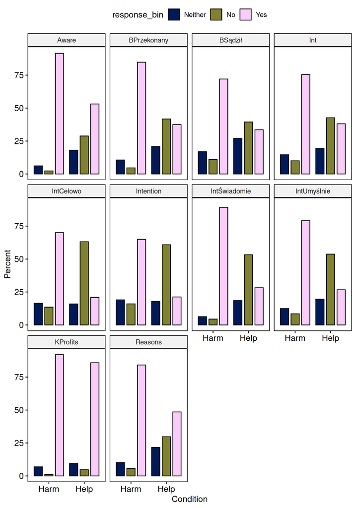